# Auto ABS Loan-level Data

T. Morrison

## Intro

This document explores the data from an ABS-EE, loan-level filing from ALLY AUTO RECEIVABLES TRUST 2017-1, the issuing entity for an auto asset-backed securitization from early 2017.

The data and other information can be found on the issuing entities page on EDGAR, the Securities and Exchange Commision’s online filing portal, [here](https://www.sec.gov/cgi-bin/browse-edgar?action=getcompany&CIK=0001679731&type=&dateb=&owner=include&start=40&count=40). A detailed overview of the security can be found in the prospectus [here](https://www.sec.gov/Archives/edgar/data/1477336/000119312517013005/d226963d424h.htm), from January, 2017.

Very simply, in auto ABS a large number of auto loans are pooled together and the cash flow from this pool is sold by the loan issuer. These many thousands of loans produce monthly cash flow in the form of principal and interest payments. Financial securities, or notes, are sold, on which the noteholders collect interest and principal payments. The loans in the pool are also known as the receivables.

So, the performance of the securitization is driven by the performance of the receivables, the auto loans. With the ABS-EE disclosures, we have access to loan-level data for every publicly-issued auto ABS.

## ABS-EE Filings

ABS-EE filings were required beginning in early 2017 as part of regulations passed following the financial crisis. The loan-level data is meant to make the security more transparent, and lower the risk. A main driver of the financial crisis was mortgage ABS, and these regulations are meant to lessen the likelihood of that happening again.

The reports are filed monthly in XML format. This is a heavyweight data format, and the files can be quite large when the number of underlying assets goes into the tens of thousands. XML is also not a useful format for using data, so I have converted it into tabular form using a detailed R script that runs in parallel; it takes about 7 minutes to process a 50,000 asset XML file. These transformed tables are then stored on a MySQL database on Amazon AWS.

## Exploratory Stats

The securitization consists of 69,007 loans. The first reporting period for which data is available is Jan, 2017. This is not the first payment date for the loans in the securitization. The origination dates vary widely across the set of loans.

Some key loan-level variables in the dataset are:

- original loan amount
- original interest rate
- loan origination date
- remaining terms to maturity (from reporting period)
- credit score
- payment to income ratio
- remaining loan balance
- reporting period scheduled payment amount
- reporting period actual amount paid
- vehicle make, model, and year

In all, the data has over 60 variables for each asset.

## The Payoff

How does the securitization work?

An asset-backed securitization is made up of individual auto loans, or in some cases leases.

In an auto loan, the loan recipient gets a sum of money, which they then pay back over time with interest. The loan is set to be paid off over a fixed amount of months, in monthly installments. With this number of months known, a constant monthly amount can be calculated, which will result in the loan being paid off over the specified time period. This is called amortization.

With the constant monthly payment, a portion of the payment goes to pay off the principal, which is then lower for the next payment, so the interest payable is lower next time. This is best illustrated with a chart. In this scenario, the loan is originated for $1,000 at an interest rate of 5%, to be paid off over 12 months.

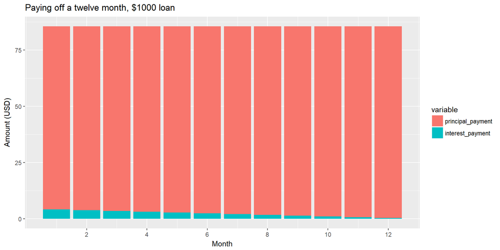

In the above example, the party making the loan would receive the sum of the principal, $1,000, plus the sum of the interest, $27.29, over the course of the twelve months.

Because an auto ABS security is made up of a large number of these loans, and we have the necessary data points to calculate the remaining amortization for each loan, we can calculate how the revenue collected by the entire security, should every loan recipient pay exactly according to their payment schedule.

#### Using the data

To accomplish this, I have created a function that uses the loan-level data from every individual loan in the dataset, using the original loan balance amount, the interest rate and the remaining principal amount at the first reporting period. This function then calculates the amortization table for every loan and combines them.

The months remaining to maturity on the loans as of the first reporting period differ: 2600 had less than 10 months as of January 2017, while 49,000 had over 40 months left to pay off the principal. Because more loans are being paid off each month, the total amount collected should diminish in the scenario where every loan is paid according to schedule. We can see that in the result:

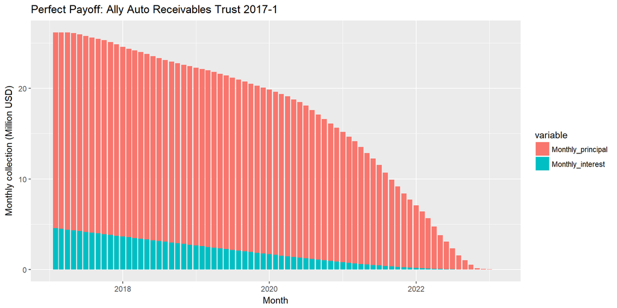

The above plot illustrates how much would be expected if every loan in the securitization paid off exactly according to their remaining amortization table. If that were the case, the entire pool of loans would be paid back, with interest, in 73 months, collecting $1,211,962,243. The outstanding principal amount from the end of the first reporting period was $1,079,285,879.

However, in auto loans, the borrower has two other options aside from paying off the loan the same amount every month: pay back more, or pay back less.

## Payment deviations

Looking at just the first reporting month, we see a lot of deviation from the scheduled payment amount. Of the 69,007 loans, 42,604 paid exactly as much as they were scheduled to pay in month one. A further 9,110 borrowers paid back between $1 and $100 more than they owed in the reporting period. And 2,705 borrowers paid more than $500 dollars over what they were scheduled to pay. At the same time, 4,899 borrowers underpaid by $100 or more in the first month.

Why would someone overpay? It reduces the principal amount faster, thereby reducing the interest one pays over the time period. Why underpay? Hard times, miss a payment, money had to go to an emergency. It could be a one month blip, with the getting back on track over the next months, or it could lead to becoming delinquent on the loan.

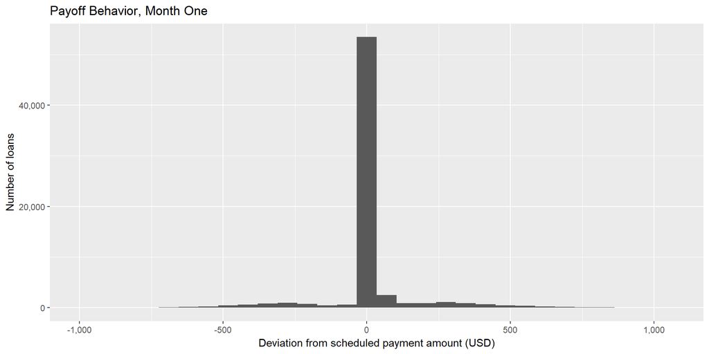

In month one, looking at the data, the scheduled total payment amount was $27,106,153 and the actual total payment amount was $42,220,951. This overpayment has an implication for the security.

#### What’s the difference?

Why does the rate at which the borrowers pay off their loans matter? The noteholders, the people and institutions that buy the ABS notes, collect principal and interest. This is not exactly related to the amount of principal in the pool: say the issuer issues notes with a $100 million principal balance. The cashflow from the loan pool (principal+interest payments) is used to pay down the outstanding note principal and the interest on it.

The monthly amount allocated to pay down the principal balance is not preset- if the pool generates $50 million in the first month, the interest on the outstanding note principal balance will be paid to all noteholders, and (almost) all the rest goes to pay off the principal balance. If it only generated $5 million in that first month, less principal gets paid off and the noteholders get more interest overall.

This is a tradeoff for the noteholders, who have expectations of how much money they will make (in interest) and how fast they will get all their money back. In addition to how fast or slow the original borrowers pay off their auto loans, their is also the chance they simply do not pay off the loans. This is not good for the noteholders, because the loan is charged off and stops paying into the pool. If this happens to too many, it can affect how much principal can be paid off and the investors in the notes will lose money.

#### Reality vs. Expectations

Obviously, we can’t expect the payment to look like the example from above. How do the receivables actually pay off? The answer is in the data:

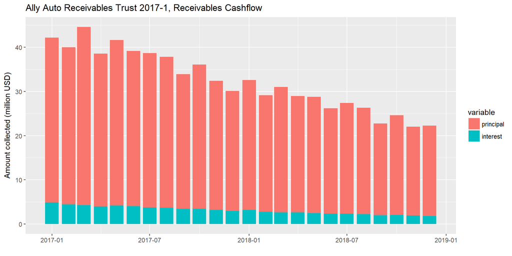

How does this compare to the model from earlier?

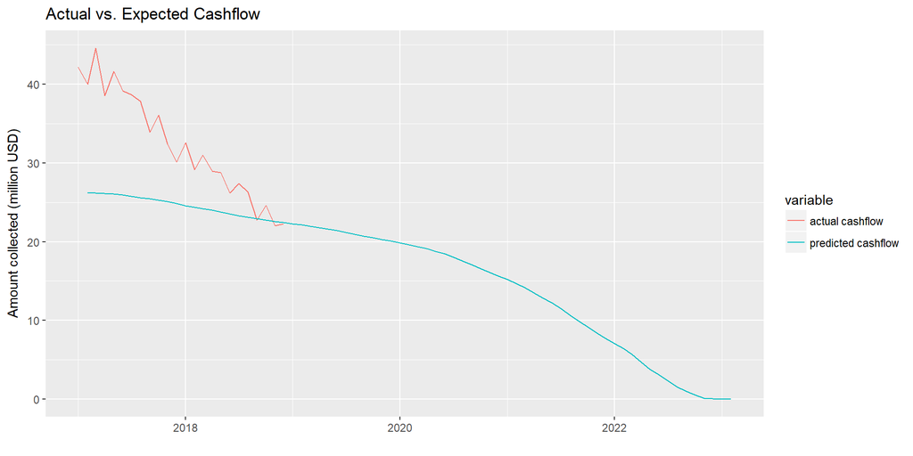

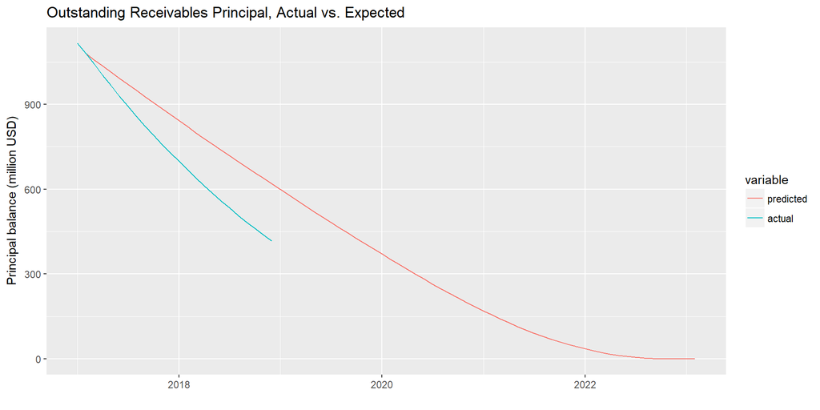

At this rate, the receivables pool looks like it will pay off a lot more quickly than would be expected. Why? I will explore this question in later analyses, looking at what characteristics of the loan-level data may affect repayment rates. There are lots of variables to explore.

Thanks for reading.